# Linear Regression

RPub URL:

http://rpubs.com/kiichi/28414

### Model

```
Y=b0+b1Xi+Ei ... where Ei are iid N(0,σ2)

b1=Cor(Y,X) * (Sd(Y)/Sd(X))
b0=Y−b1X
```

### Sample Data

```
library(UsingR)
data(mtcars)
```

```
[, 1]    mpg   Miles/(US) gallon
[, 2]    cyl     Number of cylinders
[, 3]    disp    Displacement (cu.in.)
[, 4]    hp  Gross horsepower
[, 5]    drat    Rear axle ratio
[, 6]    wt  Weight (lb/1000)
[, 7]    qsec    1/4 mile time
[, 8]    vs  V/S
[, 9]    am  Transmission (0 = automatic, 1 = manual)
[,10]    gear    Number of forward gears
[,11]    carb    Number of carburetors
```

### Single Variable Linear Regression Model

Interpreting Data

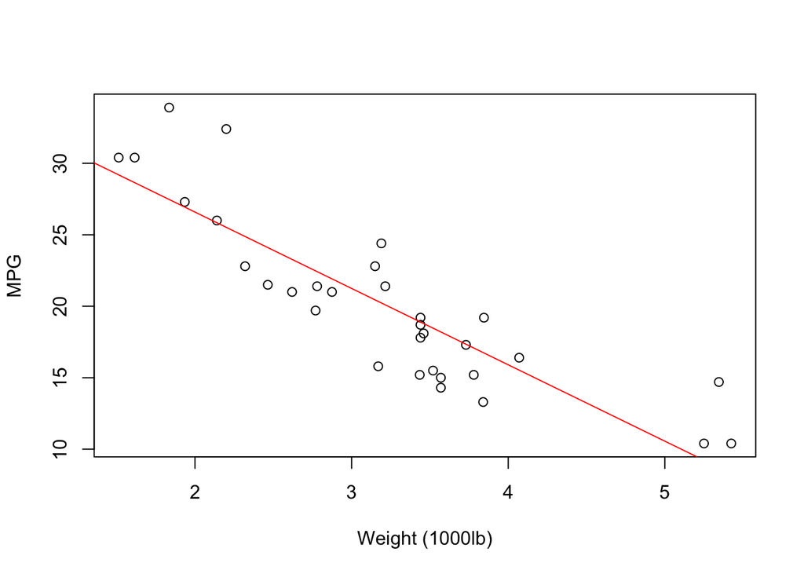

```r
x<-mtcars$wt
y<-mtcars$mpg
fit<-lm(y ~ x)
plot(x,y,xlab='Weight (1000lb)',ylab='MPG')
abline(fit,col="red")
```

Let’s look at slope and intercept

```r
coef(fit)
```

```
## (Intercept)           x
##      37.285      -5.344
```

This means, **“For every 1000lb weight increases, MPG decreases by 5.3 miles per gallon”** and **“If there is 0lb car, the MPG is 37.2 miles per gallon”**

### Centering and Scaling

How about if we need to scale / convert the unit of weight in Kg instead of lb? One way is to convert everything before applying lm() function.

```
# 1lb is 0.45kg
x<-mtcars$wg * 0.45
```

or, use I() function to scale within formula

```r
fit2<-lm(y~I(x*0.45))
coef(fit2)
```

```
## (Intercept) I(x * 0.45)
##       37.29      -11.88
```

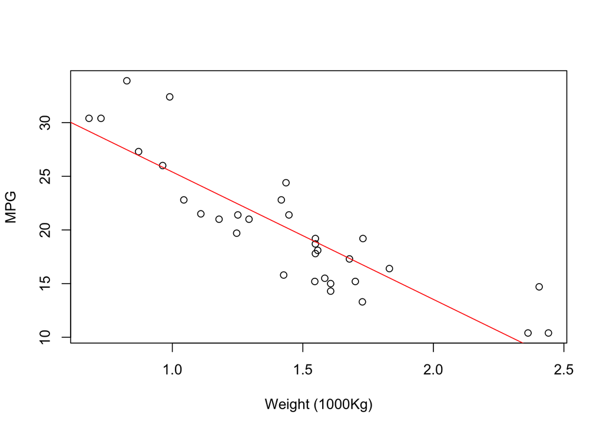

```r
plot(x*0.45,y,xlab='Weight (1000Kg)',ylab='MPG')
abline(fit2,col="red")
```

This means, **“For every 1000kg weight increases, MPG decreases by -11.88 miles per gallon”**.

In same way, you can apply centering on the formula itself. Center and scale them with the standard deviation.

```r
fit3<-lm( I( (y - mean(y))/sd(y) ) ~ I( (x - mean(x))/sd(x) ) )
coef(fit3)
```

```
##            (Intercept) I((x - mean(x))/sd(x))
##              8.053e-17             -8.677e-01
```

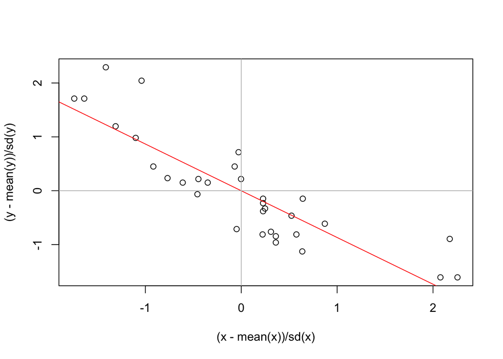

```r
plot((x - mean(x))/sd(x),(y - mean(y))/sd(y))
abline(fit3,col="red")
abline(h=0,col="gray")
abline(v=0,col="gray")
```

### Prediction

Use predict() function. You can also calculate the values from slope and intercept from coef() function.

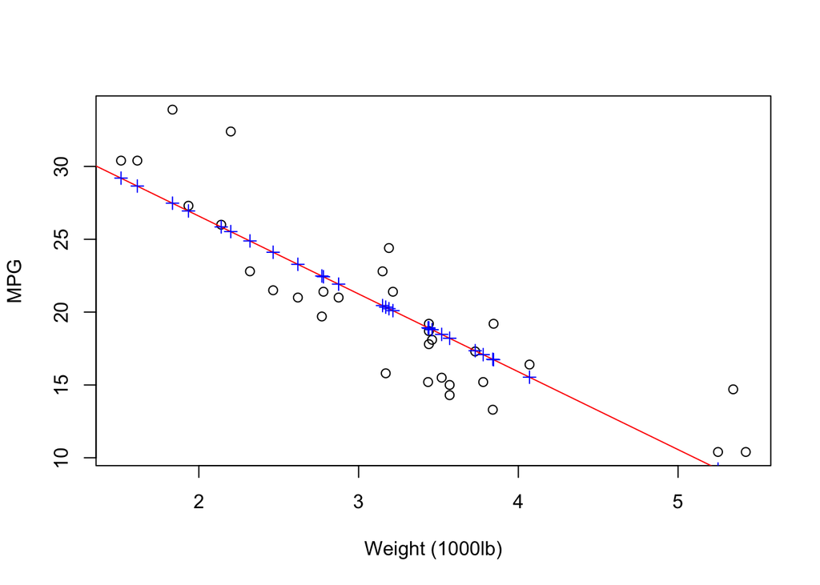

```r
est<-predict(fit,data.frame(x))

plot(x,y,xlab='Weight (1000lb)',ylab='MPG')
abline(fit,col="red")
points(x,est,col="blue",pch=3)
```

### Drawing Prediction Interval Lines

Prediction Interval

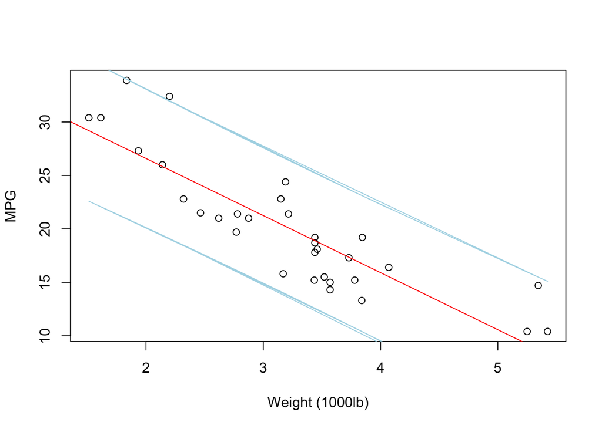

```r
p2<-predict(fit,data.frame(x), interval="prediction")
plot(x,y,xlab='Weight (1000lb)',ylab='MPG')
abline(fit,col="red")
lines(x,p2[,2],col="lightblue")
lines(x,p2[,3],col="lightblue")
```

### Residuals

Use resid() function.

```r
est<-predict(fit,newdata=data.frame(x))
err<-resid(fit)
```

Both should match:

- Gap between estimated value and real values (y-est)
- Residuals (err)

```r
head(y-est)
```

```
##       1       2       3       4       5       6
## -2.2826 -0.9198 -2.0860  1.2973 -0.2001 -0.6933
```

```r
head(err)
```

```
##       1       2       3       4       5       6
## -2.2826 -0.9198 -2.0860  1.2973 -0.2001 -0.6933
```

Draw the residuals in green bar

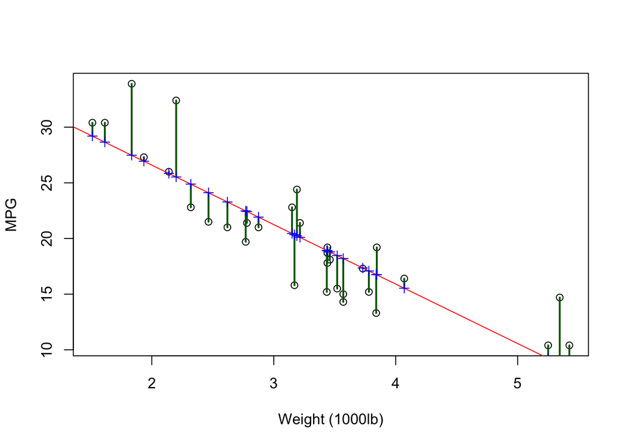

```r
plot(x,y,xlab='Weight (1000lb)',ylab='MPG')
segments(x,y,x,est, col="darkgreen", lwd = 2)
abline(fit,col="red")
points(x,est, col="blue", pch=3)
```

What is the residual variation, sigma? This indicates how good the fit is.

```r
summary(fit)$sigma
```

```
## [1] 3.046
```

Which is calculated in this way (same result)

```r
n<-length(x)
sqrt( sum(resid(fit)^2) / (n-2) )
```

```
## [1] 3.046
```

Also, see appendix below for comparing different models and misleading examples.

### P-Value

Use summary() function for p-value.

p-value is the probability to have a value equal to or greater than the observed value.

If alpha (first type error) is equal to 0.05, then:

- we refuse the null hypothesis when p-value is lower than 0.05
- we accept the null hypothesis when p-value is equal to or greater than 0.05

```r
summary(fit)
```

```
##
## Call:
## lm(formula = y ~ x)
##
## Residuals:
##    Min     1Q Median     3Q    Max
## -4.543 -2.365 -0.125  1.410  6.873
##
## Coefficients:
##             Estimate Std. Error t value Pr(>|t|)
## (Intercept)   37.285      1.878   19.86  < 2e-16 ***
## x             -5.344      0.559   -9.56  1.3e-10 ***
## ---
## Signif. codes:  0 '***' 0.001 '**' 0.01 '*' 0.05 '.' 0.1 ' ' 1
##
## Residual standard error: 3.05 on 30 degrees of freedom
## Multiple R-squared:  0.753,  Adjusted R-squared:  0.745
## F-statistic: 91.4 on 1 and 30 DF,  p-value: 1.29e-10
```

```r
#direct access to p-value
#names(summary(fit))
summary(fit)$coefficients[2,4]
```

```
## [1] 1.294e-10
```

```r
t.test(x,y)$p.value
```

```
## [1] 1.028e-16
```

R Squared Value

```r
summary(fit)$r.squared
```

```
## [1] 0.7528
```

### T-Tests and Confidence Interval

```r
tbl<-summary(fit)$coefficients
tbl
```

```
##             Estimate Std. Error t value  Pr(>|t|)
## (Intercept)   37.285     1.8776  19.858 8.242e-19
## x             -5.344     0.5591  -9.559 1.294e-10
```

```r
mn<-tbl[2,1]      #mean is the estimated slope
std_err<-tbl[2,2] #standard error
deg_fr<-fit$df    #degree of freedom

#Two sides T-Tests
mn + c(-1,1) * qt(0.975,df=deg_fr) * std_err
```

```
## [1] -6.486 -4.203
```

Conclusion:

**With 95% confidence, we estimate that every 1000lb weight increases, MPG decreases within -6.486 and -4.203 MGP**

### Drawing Confidence Interval Lines

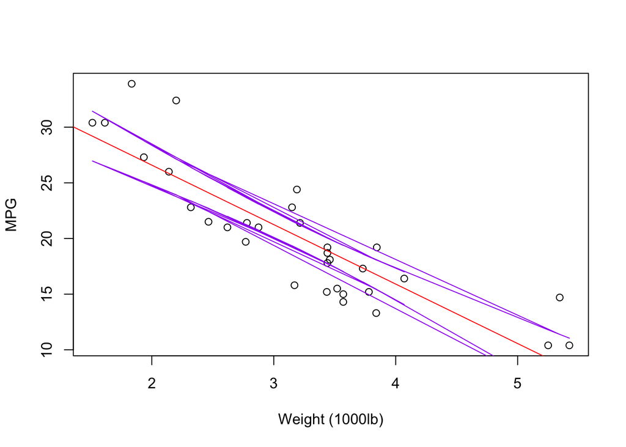

```r
p1<-predict(fit,data.frame(x), interval="confidence")
plot(x,y,xlab='Weight (1000lb)',ylab='MPG')
abline(fit,col="red")
lines(x,p1[,2],col="purple")
lines(x,p1[,3],col="purple")
```

The actual values of upper and lowers are displayed below:

```r
p1<-predict(fit,data.frame(x), interval="confidence")
#combine predictor, outcome, estimate, lower and upper
head(cbind(x,y,p1)[order(x),])
```

```
##        x    y   fit   lwr   upr
## 28 1.513 30.4 29.20 26.96 31.43
## 19 1.615 30.4 28.65 26.52 30.79
## 20 1.835 33.9 27.48 25.55 29.40
## 26 1.935 27.3 26.94 25.11 28.77
## 27 2.140 26.0 25.85 24.20 27.50
## 18 2.200 32.4 25.53 23.93 27.13
```

What about specific value to predict? What is the mpg when the weight is 2000lb?

```r
predict(fit,data.frame(x=2), interval="confidence")
```

```
##    fit   lwr   upr
## 1 26.6 24.82 28.37
```

### Multivariate Linear Regression Model

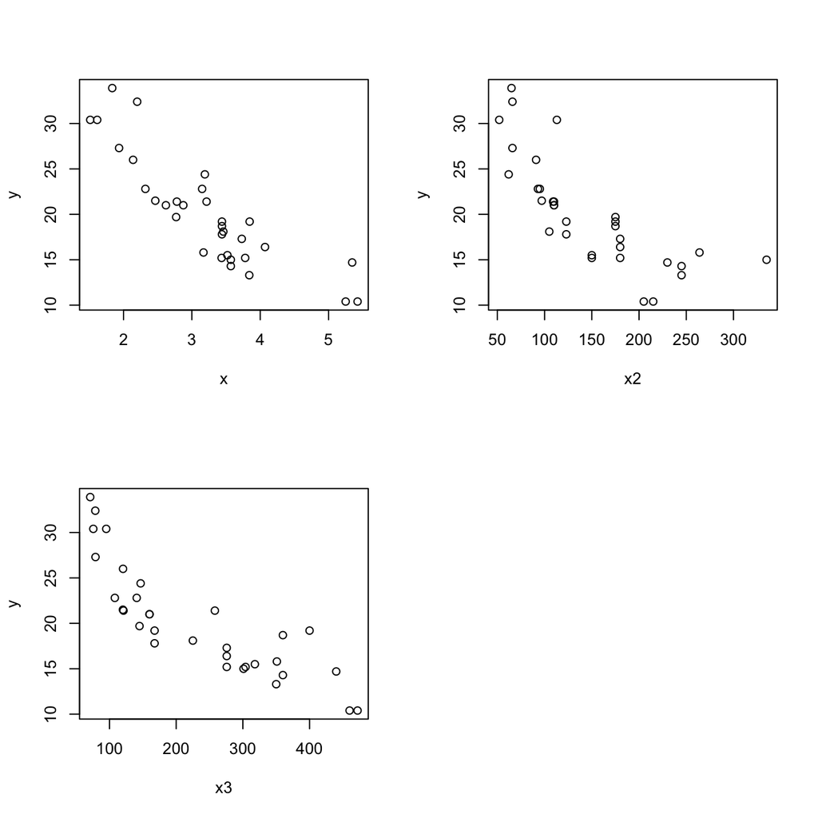

```r
x<-mtcars$wt
x2<-mtcars$hp
x3<-mtcars$disp
y<-mtcars$mpg

par(mfrow=c(2,2))
plot(x,y)
plot(x2,y)
plot(x3,y)
```

Find residuals

```r
#-1 removes the intercept term
coef(lm(y ~ x + x2 + x3 - 1))
```

```
##        x       x2       x3
## 12.06391  0.04382 -0.11686
```

Which is same as

```r
ex<-resid(lm(x ~ x2 + x3 - 1))
ey<-resid(lm(y ~ x2 + x3 - 1))
sum(ex * ey) / sum(ex^2)
```

```
## [1] 12.06
```

### Appendix 1: Models with / without slope and intercept

- **Model with Slope & Intercept** v.s.
- **Model with only Intercept** v.s.
- **Only Slope**

Fit without slope (Horizontal)

```r
fit_no_slope<-lm(y ~ 1)
```

Fit without intercept = force to go throuh (0,0)

```r
fit_no_intercept<-lm(y ~ x - 1)
```

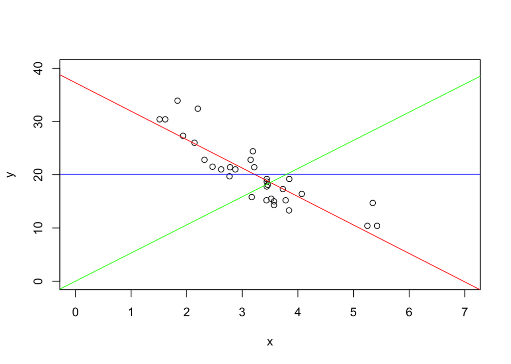

```r
plot(x,y,xlim=c(0,7),ylim=c(0,40))
abline(fit,col="red")
abline(fit_no_slope,col="blue")
abline(fit_no_intercept,col="green")
```

How can we measure which one is the best model? It’s obvious, but let’s verify it. Use Sigma.

```r
c(summary(fit)$sigma,
  summary(fit_no_slope)$sigma,
  summary(fit_no_intercept)$sigma)
```

```
## [1]  3.046  6.027 11.269
```

Sum Sq Values Comparison

```r
c(anova(fit)[1,'Sum Sq'],
  anova(fit_no_slope)[1,'Sum Sq'],
  anova(fit_no_intercept)[1,'Sum Sq'])
```

```
## [1]   847.7  1126.0 10105.7
```

```r
anova(fit,fit_no_slope,fit_no_intercept)
```

```
## Analysis of Variance Table
##
## Model 1: y ~ x
## Model 2: y ~ 1
## Model 3: y ~ x - 1
##   Res.Df  RSS Df Sum of Sq    F  Pr(>F)
## 1     30  278
## 2     31 1126 -1      -848 91.4 1.3e-10 ***
## 3     31 3937  0     -2811
## ---
## Signif. codes:  0 '***' 0.001 '**' 0.01 '*' 0.05 '.' 0.1 ' ' 1
```

Check R Squared Values

```r
c(summary(fit)$r.squared,
  summary(fit_no_slope)$r.squared,
  summary(fit_no_intercept)$r.squared)
```

```
## [1] 0.7528 0.0000 0.7197
```

Note: the linear model without slope shows 0 for sum of redistuals. Residual values are canceled out each other; however sigma is larger than the best fit one.

### Appendix 2: Misleading Examples

Below 4 different datasets show the same slope, and also sigmas and Sum Sq are same.

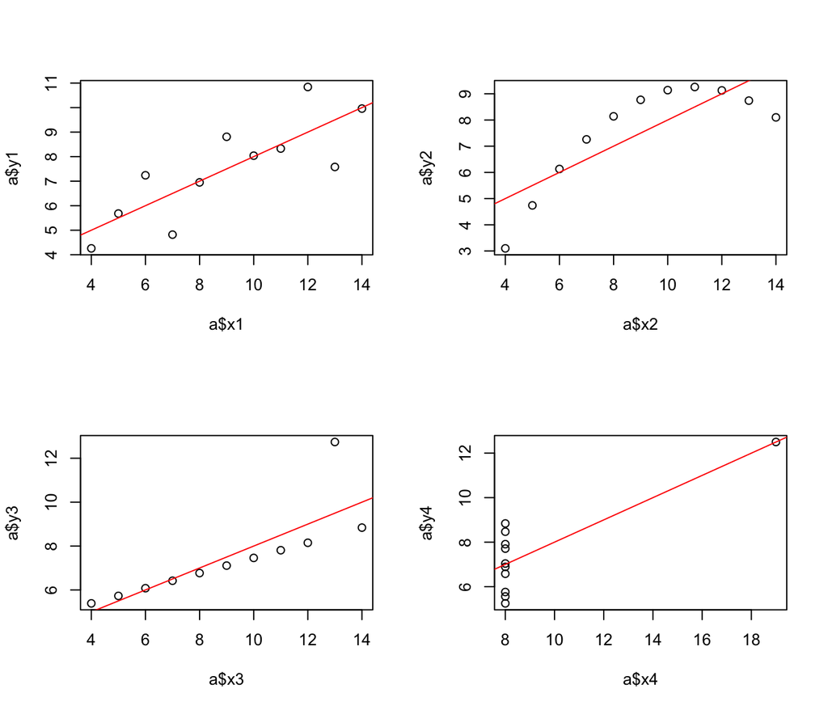

```r
data(anscombe)
par(mfrow=c(2,2))
a<-anscombe
f1<-lm(a$y1~a$x1)
f2<-lm(a$y2~a$x2)
f3<-lm(a$y3~a$x3)
f4<-lm(a$y4~a$x4)

plot(a$x1,a$y1)
abline(f1,col="red")
plot(a$x2,a$y2)
abline(f2,col="red")
plot(a$x3,a$y3)
abline(f3,col="red")
plot(a$x4,a$y4)
abline(f4,col="red")
```

*You can also call example(anscombe)*

Compare Sigmas. They are same.

```r
c(summary(f1)$sigma,
summary(f2)$sigma,
summary(f3)$sigma,
summary(f4)$sigma)
```

```
## [1] 1.237 1.237 1.236 1.236
```

Compare Sum Sq. They are same.

```r
c(anova(f1)[1,'Sum Sq'],
  anova(f2)[1,'Sum Sq'],
  anova(f3)[1,'Sum Sq'],
  anova(f4)[1,'Sum Sq'])
```

```
## [1] 27.51 27.50 27.47 27.49
```

Compare R-Squared Values. They are same.

```r
c(summary(f1)$r.squared,
summary(f2)$r.squared,
summary(f3)$r.squared,
summary(f4)$r.squared)
```

```
## [1] 0.6665 0.6662 0.6663 0.6667
```